**Dragos Ailoae**

Applied Statistics and Econometrics 1

2022-10-05

# Partitioned Regression and the Frisch-Waugh-Lovell Theorem

### Theory

(Based on Greene textbook)

Suppose that the regression involves two sets of variables, $\mathbf{X}_1$ and $\mathbf{X}_2$. Thus,

$$ \mathbf{y}=\mathbf{X} \boldsymbol{\beta}+\boldsymbol{\varepsilon}=\mathbf{X}_1 \boldsymbol{\beta}_1+\mathbf{X}_2 \boldsymbol{\beta}_2+\boldsymbol{\varepsilon} . $$

What is the algebraic solution for $\mathbf{b}_2$ ? The normal equations are

$$\left[\begin{array}{ll}\mathbf{X}_1^{\prime} \mathbf{X}_1 & \mathbf{X}_1^{\prime} \mathbf{X}_2 \\ \mathbf{X}_2^{\prime} \mathbf{X}_1 & \mathbf{X}_2^{\prime} \mathbf{X}_2\end{array}\right]\left[\begin{array}{l}\mathbf{b}_1 \\ \mathbf{b}_2\end{array}\right]=\left[\begin{array}{l}\mathbf{X}_1^{\prime} \mathbf{y} \\ \mathbf{X}_2^{\prime} \mathbf{y}\end{array}\right]$$

A solution can be obtained by using the partitioned inverse matrix of (Greene appendix A-74). Alternatively, the two individual equations can be manipulated directly to solve for $\mathbf{b}_2$. We first solve equation (1) for $\mathbf{b}_1$ :

$$ \begin{aligned} &\mathbf{X}_1^{\prime} \mathbf{X}_1 \mathbf{b}_1+\mathbf{X}_1^{\prime} \mathbf{X}_2 \mathbf{b}_2=\mathbf{X}_1^{\prime} \mathbf{y}, \\ &\mathbf{b}_1=\left(\mathbf{X}_1^{\prime} \mathbf{X}_1\right)^{-1} \mathbf{X}_1^{\prime} \mathbf{y}-\left(\mathbf{X}_1^{\prime} \mathbf{X}_1\right)^{-1} \mathbf{X}_1^{\prime} \mathbf{X}_2 \mathbf{b}_2=\left(\mathbf{X}_1^{\prime} \mathbf{X}_1\right)^{-1} \mathbf{X}_1^{\prime}\left(\mathbf{y}-\mathbf{X}_2 \mathbf{b}_2\right) \end{aligned} $$

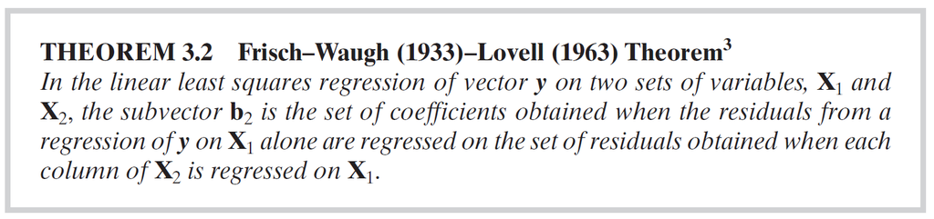

To prove it, begin from equation (2), which is $$ \mathbf{X}_2^{\prime} \mathbf{X}_1 \mathbf{b}_1+\mathbf{X}_2^{\prime} \mathbf{X}_2 \mathbf{b}_2=\mathbf{X}_2^{\prime} \mathbf{y} . $$ Now, insert the result for $\mathbf{b}_1$ into this result. This produces

$$ \mathbf{X}_2^{\prime} \mathbf{X}_1\left(\mathbf{X}_1^{\prime} \mathbf{X}_1\right)^{-1} \mathbf{X}_1^{\prime} \mathbf{y}-\mathbf{X}_2^{\prime} \mathbf{X}_1\left(\mathbf{X}_1^{\prime} \mathbf{X}_1\right)^{-1} \mathbf{X}_1^{\prime} \mathbf{X}_2 \mathbf{b}_2+\mathbf{X}_2^{\prime} \mathbf{X}_2 \mathbf{b}_2=\mathbf{X}_2^{\prime} \mathbf{y} . $$

After collecting terms, the solution is

$$ \begin{aligned} \mathbf{b}_2 &=\left[\mathbf{X}_2^{\prime}\left(\mathbf{I}-\mathbf{X}_1\left(\mathbf{X}_1^{\prime} \mathbf{X}_1\right)^{-1} \mathbf{X}_1^{\prime}\right) \mathbf{X}_2\right]^{-1}\left[\mathbf{X}_2^{\prime}\left(\mathbf{I}-\mathbf{X}_1\left(\mathbf{X}_1^{\prime} \mathbf{X}_1\right)^{-1} \mathbf{X}_1^{\prime}\right) \mathbf{y}\right] \\ &=\left(\mathbf{X}_2^{\prime} \mathbf{M}_1 \mathbf{X}_2\right)^{-1}\left(\mathbf{X}_2^{\prime} \mathbf{M}_1 \mathbf{y}\right) \end{aligned} $$

The $\mathbf{M}_1$ matrix appearing in the parentheses inside each set of parentheses is the "residual maker", in this case defined for a regression on the columns of $\mathbf{X}_1$. Thus, $\mathbf{M}_1 \mathbf{X}_2$ is a matrix of residuals; each column of $\mathbf{M}_1 \mathbf{X}_2$ is a vector of residuals in the regression of the corresponding column of $\mathbf{X}_2$ on the variables in $\mathbf{X}_1$. By exploiting the fact that $\mathbf{M}_1$, like $\mathbf{M}$, is symmetric and idempotent, we can rewrite as

$$ \mathbf{b}_2=\left(\mathbf{X}_2^* \mathbf{X}_2^*\right)^{-1} \mathbf{X}_2^* \mathbf{y}^*, $$

where $\mathbf{X}_2^*=\mathbf{M}_1 \mathbf{X}_2$ and $\mathbf{y}_*=\mathbf{M}_1 \mathbf{y}$. This result is fundamental in regression analysis.

### Example using matrices

```r
#FWL Example:
X <- matrix(c(1,1,2,
              1,4,7,
              1,5,9,
              1,6,8), byrow = TRUE, 4)

Y <- matrix(c(4,5,7,12),4,1)

beta.hat <- solve(t(X) %*% X) %*% t(X) %*% Y
beta.hat
```

| 3.5 |
| --- |
| 3.8 |
| -1.8 |

```r
X1 <- matrix(c(1,1,
               1,4,
               1,5,
               1,6), byrow = TRUE, 4)

#Least Squares Example:
X2 <- matrix(c(2,
               7,
               9,
               8), byrow = TRUE, 4)

P1 <- X1 %*% solve(t(X1) %*% X1) %*% t(X1)

M1 <- diag(dim(P1)[1]) - P1

beta.hat.2 <- solve(t(X2) %*% M1 %*% X2) %*% t(X2) %*% M1 %*% Y
beta.hat.2
```

| -1.8 |
| --- |

### Example using the 'lm' function

```r
rm(list=ls())    # Removes all items in Environment!
#
# LOAD PACKAGES:
packages <- c("stargazer")
# Loop though vector and load respective packages with options:
qzzz <- lapply(packages, require, character.only = TRUE) # verbose
#

## Generate random data
set.seed(12345)
df <- data.frame(y = rnorm(1000,2,1.5),
                 x1 = rnorm(1000,1,0.3),
                 x2 = rnorm(1000,1,4))

# Multivariate regression:
my.multivar.lm <- lm(y ~ x1 + x2, df)
stargazer(my.multivar.lm, type="text")
```

```
===============================================
                        Dependent variable:
                    ---------------------------
                                 y
-----------------------------------------------
x1                             0.192
                              (0.157)

x2                            -0.005
                              (0.012)

Constant                     1.884***
                              (0.163)

-----------------------------------------------
Observations                   1,000
R2                             0.002
Adjusted R2                   -0.0004
Residual Std. Error      1.498 (df = 997)
F Statistic             0.822 (df = 2; 997)
===============================================
Note:               *p<0.1; **p<0.05; ***p<0.01
```

Calculate $\hat \beta_2$ using partial univariate regression (FWL):

```r
# Residual of y regressed on x1
y_res_m1 <- lm(y ~ x1, df)$residuals

# Residual of x2 regressed on x1
x2_res_m1 <- lm(x2 ~ x1, df)$residuals

# Partials regression
my.partial.reg.b2 <- lm(y_res_m1 ~ x2_res_m1)
stargazer(my.partial.reg.b2,type="text")
```

```
===============================================
                        Dependent variable:
                    ---------------------------
                             y_res_m1
-----------------------------------------------
x2_res_m1                     -0.005
                              (0.012)

Constant                      -0.000
                              (0.047)

-----------------------------------------------
Observations                   1,000
R2                            0.0001
Adjusted R2                   -0.001
Residual Std. Error      1.498 (df = 998)
F Statistic             0.142 (df = 1; 998)
===============================================
Note:               *p<0.1; **p<0.05; ***p<0.01
```

Alternately, Calculate $\hat \beta_1$ using partial univariate regression (FWL):

```r
# Residual of y regressed on x2
y_res_m2 <- lm(y ~ x2, df)$residuals

# Residual of x1 regressed on x2
x1_res_m2 <- lm(x1 ~ x2, df)$residuals


my.partial.reg.b1 <- lm(y_res_m2 ~ x1_res_m2)
stargazer(my.partial.reg.b1,type="text")
```

```
===============================================
                        Dependent variable:
                    ---------------------------
                             y_res_m2
-----------------------------------------------
x1_res_m2                      0.192
                              (0.157)

Constant                       0.000
                              (0.047)

-----------------------------------------------
Observations                   1,000
R2                             0.001
Adjusted R2                   0.0005
Residual Std. Error      1.498 (df = 998)
F Statistic             1.497 (df = 1; 998)
===============================================
Note:               *p<0.1; **p<0.05; ***p<0.01
```